← Voltar ao Portal

[figure not shown]

Programa 433

# Síntese Avaliativa do Desempenho dos Programas do PPA Bahia 2024–2027

# **1 - Desempenho Global do Programa**

Este documento apresenta uma Síntese Avaliativa do Desempenho do Programa do Plano Plurianual - PPA 2024- 2027, trazendo uma visão estratégica dos seus resultados, de forma sintética, transparente e colaborativa. Serão levados em consideração o Indicador Sintético de Desempenho do Programa (ISDP), a evolução dos Indicadores de Programa, a eficácia das metas dos Indicadores de Compromisso, o desempenho da execução orçamentária-financeira e da execução física das Ações orçamentárias. O ISDP é uma síntese dessas quatro dimensões, destacando o desempenho do programa em relação aos resultados obtidos e aos esforços despendidos.  
Adicionalmente, são apresentados os principais resultados alcançados, evidenciando os avanços e conformidades dos cinco programas com melhores resultados, além das oportunidades de melhoria dos cinco, com menores resultados. Enquanto neste documento a análise abrange o programa e seus componentes de maneira sintética, nos demais relatórios, a análise detalhada evidencia o comportamento dos componentes do PPA por programas e por órgãos (https://www.ba.gov.br/seplan/monitoramento-e-avaliacao/avaliacao-do-ppa). Além desta Síntese, o [Painel BI - Boletim de Avanços e Oportunidades de Melhoria](https://app.powerbi.com/view?r=eyJrIjoiN2Q0ODliNDItZDFjZi00MGM1LTliNGEtODVmZDAwZTQ1OGEyIiwidCI6IjRjZDgzNWY0LTU0NDAtNDA4Zi05M2EzLTk3NWZjMTdjMzg0YSIsImMiOjR9) oferece informações organizadas em uma perspectiva estratégica do desempenho consolidado dos programas, detalhando, no entanto, cada componente avaliado. A análise nesta seção engloba o programa e seus componentes conforme segue:

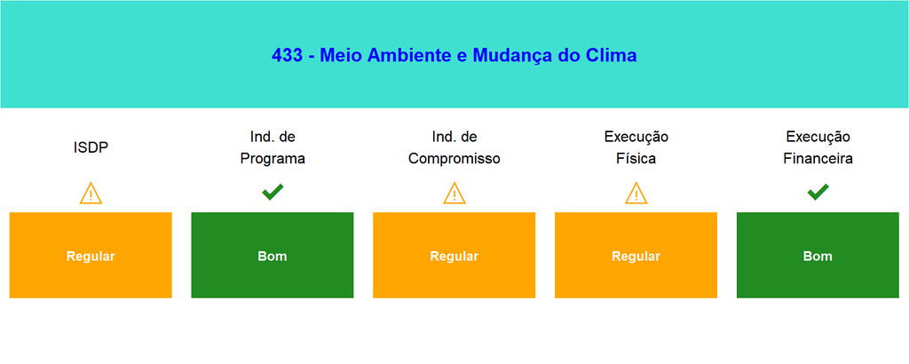

# **2 - Avanços e Conformidades no Programa**

**Indicadores de Programa:** No programa 433 - Meio Ambiente e Mudança do Clima, 77,8% dos indicadores apresentaram evolução positiva. O indicador 2208, que monitora a área queimada na Bahia, obteve uma redução de 10,01%. Essa melhoria pode ser atribuída a parcerias e ações preventivas, como a Caravana do Bahia Sem Fogo, além de atividades educativas e de fiscalização, que envolveram o Corpo de Bombeiros. Em 2025, houve um maior engajamento das instituições envolvidas no programa, incluindo comunidades tradicionais e brigadistas.  
**Indicadores de Compromisso:** No programa 433 - Meio Ambiente e Mudança do Clima, 42,1% dos indicadores de compromisso tiveram desempenho bom ou ótimo. O indicador ‘1 - Número de brigadistas voluntários de combate aos incêndios florestais capacitados’ obteve 91,93%. Esse resultado foi impactado por mudanças normativas que atrasaram a oferta de cursos de formação, embora as ações estejam alinhadas ao planejamento institucional e busquem fortalecer a eficácia das atividades. Além disso, o indicador ‘5 - Número de imóveis rurais finalizados no Cadastro Estadual Florestal de Imóveis Rurais - CEFIR’ alcançou 104,2%, resultado de um maior empenho do órgão em otimizar os serviços de apuração.  
**Ações Orçamentárias:** No Programa 433 - Meio Ambiente e Mudança do Clima, 52,1% das ações mostraram bom ou ótimo desempenho financeiro, enquanto 48,3% foram classificadas com a mesma performance na execução física. A Ação 2454 - Gerenciamento de Colegiado de Meio Ambiente e Recursos Hídricos, assim como a Ação 4612 - Prevenção e Apoio ao Combate de Incêndio Florestal, obtiveram notas ótimas.

# **3 - Oportunidade de Melhoria no Programa**

**Indicadores de Programa:** No programa 433 - Meio Ambiente e Mudança do Clima, 11,1% dos indicadores mostraram evolução negativa. O indicador 02204 - Proporção da área desmatada no Bioma Caatinga ficou inalterado. A redução da área desmatada é atribuída às ações da atual gestão, embora a economia do estado, dependente da produção de commodities, exija o uso de áreas com vegetação nativa, o que impactará negativamente esse indicador ao longo dos anos. O crescimento econômico, aliado à conservação da biodiversidade, é o modelo sustentável almejado.  
**Indicadores de Compromisso:** No Programa 433, Meio Ambiente e Mudança do Clima, 26,4% dos indicadores foram classificados como de baixo ou muito baixo desempenho, e 15,8% como indeterminados ou não aptos para avaliação. O indicador ‘1 - Número de unidades de conservação estaduais com plano de manejo elaborados’ apresentou desempenho de 0%, fruto da necessidade de extensão de prazos para atividades, que comprometeram os cronogramas. O indicador ‘2 - Área com ações de restauração implantada’ obteve 20%, resultante da restauração de 10 hectares na região do Jiquiriçá. A previsão para a formalização e início da restauração de 130 hectares na Bacia do Rio Salitre foi afetada por dificuldades de contratação, além de um edital lançado para reposição florestal no cerrado que teve baixos resultados em propostas aprovadas, gerando atrasos na execução dos projetos previstos.  
**Ações Orçamentárias:** No entanto, no Programa 433 - Meio Ambiente e Mudança do Clima, 37,5% das ações apresentaram desempenho baixo ou muito baixo na execução financeira, enquanto 44,7% foram avaliadas assim na execução física. Exemplos incluem as ações 3246 - Elaboração de Estudo e Pesquisa do Sistema Estadual de Unidades de Conservação e 3218 - Requalificação de Centro de Triagem de Animais Silvestres, classificadas como “Muito Baixo” em ambas as execuções.

Desenvolvido por: DAP – Diretoria de Avaliação de Políticas Públicas